# Learning R for biologists

# Exercise solution (5 minutes)

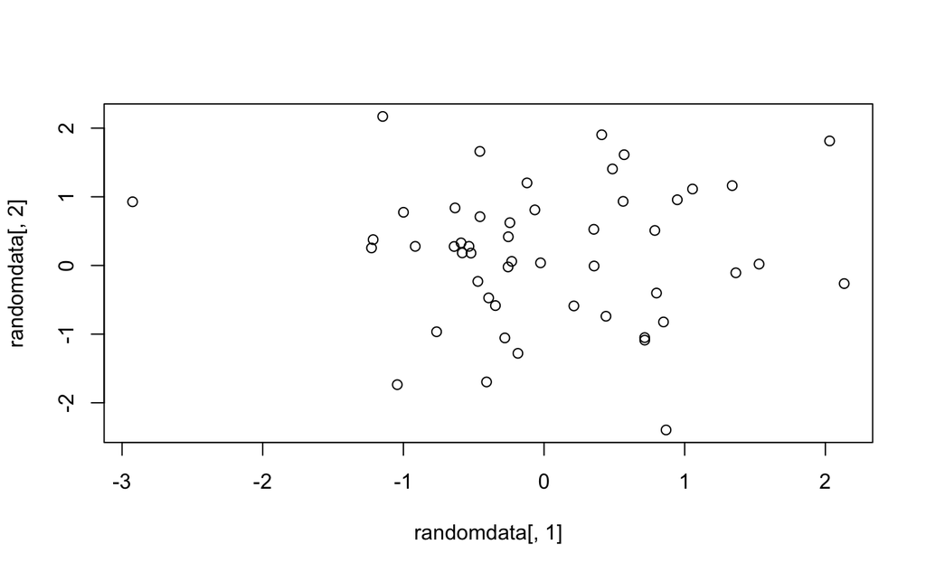

```r
# Create a matrix “randomdata” with 50 rows and 10 columns using "replicate(10,rnorm(50))"
randomdata <- replicate(10, rnorm(50))

# Plot the first and second columns of the matrix in a scatter plot
plot(randomdata[, 1], randomdata[, 2])
```

```r
# Generate a vector “randommeans” with the means of all columns of randomdata
# Generate a vector “randomsds” with the standard deviations of all columns of randomdata
# Calculate the means of all columns
randommeans <- apply(randomdata, 2, mean)
randomsds <- apply(randomdata, 2, sd)
print(randommeans)
```

```
 [1]  0.01201235  0.17672462  0.01336568  0.02032265 -0.03208256  0.02652264 -0.00355257  0.17482751 -0.09636992
[10]  0.20681141
```

```r
print(randomsds)
```

```
 [1] 0.9238712 0.9925202 0.9427915 0.7899205 0.7399413 0.9306651 0.9341593 0.8588476 0.8748150 1.1178670
```

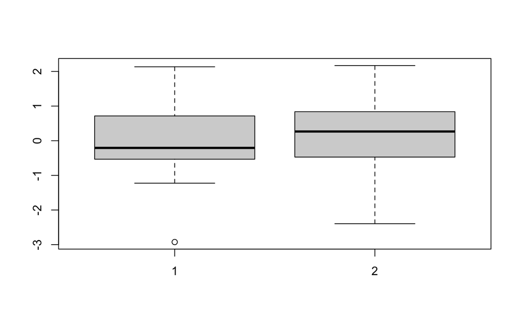

```r
# Generate a boxplot of the first and second columns of randomdata
boxplot(randomdata[, 1], randomdata[, 2])
```

# Module 8

The Book of R: Appendix A (packages)

## Module 7 review

- External programs
  - system2
- Recipes
- Introduction to plots
  - plot(runif(50), runif(50)) #x,y scatter plot
  - boxplot(runif(50))

# Packages

## Key R concept

- A place to store a set of functions
- Can create a library of functions
- Easily import the functions (and data) into R by installing the * package
- Packages are available online in package repositories
  - The Comprehensive R Archive Network (CRAN) - https://cran.r-project.org/
  - Bioconductor - https://www.bioconductor.org/
- Note: similar to functions, you may not create your own package right away, but you need to understand what they are.

# Installing packages

```r
# This downloads the package to your computer
# Permanent download – you only need to do this once
# select a mirror – choose someplace close (faster internet connection), or just the first one
install.packages("ggplot2")

# This loads the package so you can use it
# Need to do this each time you restart R
# Sometimes other packages that this package needs will automatically be downloaded – could take time.
library(ggplot2)

#now we can use the functions in the package
ggplot(iris, aes(x = Sepal.Length, fill = Species)) + geom_density(alpha = .3)
```

# Package management

```r
#List all installed packages
installed.packages()

#uninstall a package
#e.g. remove.packages(ggplot2)
#remove.packages(pkgs, lib)

#Lists packages that could be updated
old.packages()

#Update all old packages
#R will likely ask you questions about which versions to install
update.packages()
```

# Package documentation

- Website
  - https://cran.r-project.org/web/packages/kinship2/index.html
- Vignette
  - PDF file taking you through an example of the package functionality that you can follow
  - The first documentation you should review for any package

# Example: kinship2 package

```r
install.packages("kinship2")
library(kinship2)
data(sample.ped) #load sample data
head(sample.ped)
pedAll = pedigree(id=sample.ped$id, dadid=sample.ped$father, momid=sample.ped$mother, sex=sample.ped$sex, famid=sample.ped$ped)
ped2basic <- pedAll['2']
plot(ped2basic)
df2 <- sample.ped[sample.ped$ped==2,]
id2 <- paste(df2$id, c("John", "Linda", "Jack", "Rachel", "Joe", "Deb", "Lucy", "Ken", "Barb", "Mike", "Matt", "Mindy", "Mark", "George"), sep="\n")
plot(ped2basic, col=ifelse(df2$avail, 2, 1), id=id2)
```

# Bioconductor

- Over 1000 bioinformatics packages
- Gene expression
  - Import Affymetrix, Illumina, Nimblegen, Agilent, and other platforms. Perform quality assessment, normalization, differential expression, clustering, classification, gene set enrichment, genetical genomics and other workflows for expression, exon, copy number, SNP, methylation and other assays. Access GEO, ArrayExpress, Biomart, UCSC, and other community resources.
- High Throughput Assays
  - Import, transform, edit, analyze and visualize flow cytometric, mass spec, HTqPCR, cell-based, and other assays.
- Sequence Data
  - Import fasta, fastq, ELAND, MAQ, BWA, Bowtie, BAM, gff, bed, wig, and other sequence formats. Trim, transform, align, and manipulate sequences. Perform quality assessment, ChIP-seq, differential expression, RNA-seq, and other workflows. Access the Sequence Read Archive.
- Annotation
  - Use microarray probe, gene, pathway, gene ontology, homology and other annotations. Access GO, KEGG, NCBI, Biomart, UCSC, vendor, and other sources.

# Creating your own package

```r
#Install needed packages
install.packages("devtools")
library("devtools")
install.packages("roxygen2")
library(roxygen2)

#Create a directory for your package
#setwd("parent_directory")
#Create the directory 'mypackage' inside of 'parent_directory'
create("mypackage")
```

- Save functions in a file in:
  - parent_directory/mypackage/R
  - Example – copy the following files into this folder
    - lengthfunction.r
    - regexfunction.r
  - Can also save each function as a separate file for organizational purposes
- Write documentation
  - Edit DESCRIPTION text file
  - Write documentation for each function using
    - https://cran.r-project.org/web/packages/roxygen2/

```r
#Function documentation example
#' The length of a string (in characters).
#'
#' @param string input character vector
#' @return numeric vector giving number of characters in each element of the
#'   character vector.  Missing strings have missing length.
#' @seealso \code{\link{nchar}} which this function wraps
#' @export
#' @examples
#' str_length(letters)
#' str_length(c("i", "like", "programming", NA))
str_length <- function(string) {
  string <- check_string(string)
  nc <- nchar(string, allowNA = TRUE)
  is.na(nc) <- is.na(string)
  nc
}
```

```r
#note: setwd resets if you run it just one line at a time. You need to run the whole chunk all at once.

#Generate the documentation files
setwd("./mypackage")  #(your package directory)
document()
#Install your package
setwd("..")   #(go to parent directory)
install("mypackage")
#R copies your package to an internal directory
#Load (or activate) your package
library(mypackage)
```

```r
#Check that your package is working
help(package=mypackage)
ls("package:mypackage")
DNA = "ACACGTACTGATCGGGATATTAG"
allMatchingStrings("A.A", DNA)
str_length(DNA)
```